# LASSO Regression for Variable Selection

Marc Los Huertos

EA030 · Compiled 2026-10-24

EA030 — Advanced Statistics — Module 13

# LASSO Regression for Variable Selection

**Prof. Marc Los Huertos** • Pomona College • EA030 Environmental Analysis

← Back to Home

Why LASSO? The Intuition The Math Dataset The OLS Problem Fitting LASSO Cross-Validation Interpretation Ridge & Elastic Net Diagnostics Reporting

#### 🎯 Learning Outcomes

1. Explain why ordinary least squares (OLS) fails when the number of predictors is large relative to sample size.
2. Describe how the LASSO penalty shrinks coefficients and performs automatic variable selection.
3. Prepare a predictor matrix and response vector in the format `glmnet` requires.
4. Fit a LASSO model with `glmnet()` and interpret the coefficient path plot.
5. Use `cv.glmnet()` to choose the penalty parameter lambda by cross-validation.
6. Distinguish between `lambda.min` and `lambda.1se` and explain when each is appropriate.
7. Compare LASSO, ridge, and elastic net regression and choose the right method for a given dataset.
8. Extract, visualize, and report the selected predictors with confidence.
9. Recognize common pitfalls: failing to standardize, ignoring correlated predictors, and over-interpreting selection results.

> **What this module covers.** When you measure 15 water quality parameters at 60 sampling sites and want to know which ones predict dissolved oxygen, ordinary regression struggles. With many predictors relative to sample size, OLS overfits, coefficients become unstable, and you cannot tell which variables truly matter. **LASSO regression** solves this by adding a penalty that shrinks weak predictors exactly to zero, performing variable selection and model fitting in a single step. This tutorial teaches the complete workflow in R using the `glmnet` package, applied to a simulated water quality dataset.

## 1. Why LASSO?

In Module 11 (Multiple Regression), you learned to build models with several predictors and use AIC for model selection. AIC works well when you have a handful of candidate predictors and can enumerate plausible models. But environmental datasets often present a harder problem:

With 14 predictors, there are $2^{14} = 16{,}384$ possible models. Stepwise AIC can search this space, but it is greedy (tests one variable at a time), path-dependent (the order of entry matters), and prone to selecting spurious predictors. LASSO takes a fundamentally different approach: it fits all predictors simultaneously and lets the penalty decide which ones survive.

### Three problems LASSO solves

**1. Variable selection.** LASSO shrinks unimportant coefficients to exactly zero, giving you a sparse model automatically. You do not need to specify which predictors to test.

**2. Overfitting.** By penalizing the total size of the coefficients, LASSO trades a small increase in bias for a large decrease in variance. The resulting model predicts new data better than OLS, especially when $p$ (predictors) is large relative to $n$ (observations).

**3. Multicollinearity.** When predictors are correlated (temperature and dissolved oxygen, nitrate and phosphate), OLS coefficients become unstable and inflated. LASSO stabilizes them by forcing the model to choose among correlated predictors rather than splitting the effect across all of them.

**💡 When do you need LASSO?** A useful rule of thumb: if you have more than 5 candidate predictors and fewer than 20 observations per predictor, standard OLS with stepwise selection is unreliable. LASSO becomes the better default. If you have only 2 to 4 predictors and ample data, stick with OLS and AIC from Module 11.

## 2. The Intuition: Penalizing Complexity

OLS finds the coefficients $\hat\beta$ that minimize the residual sum of squares (RSS):

$$\text{OLS: } \quad \hat\beta =
\arg\min_\beta \sum_{i=1}^{n} (y_i - \beta_0 - \sum_{j=1}^{p} \beta_j
x_{ij})^2$$

This is the same objective function from Module 6 (Simple Linear Regression) and Module 11 (Multiple Regression). LASSO adds a single extra term: a **penalty** on the total absolute size of the coefficients.

$$\text{LASSO: } \quad \hat\beta =
\arg\min_\beta \left[ \sum_{i=1}^{n} (y_i - \beta_0 - \sum_{j=1}^{p}
\beta_j x_{ij})^2 \;+\; \lambda \sum_{j=1}^{p} |\beta_j|
\right]$$

The penalty term $\lambda \sum |\beta_j|$ makes the model pay a cost for every unit of coefficient magnitude. The parameter $\lambda$ (lambda) controls how harsh the penalty is:

- When $\lambda = 0$, there is no penalty, and LASSO reduces to OLS.
- As $\lambda$ increases, more coefficients are shrunk toward zero.
- At a sufficiently large $\lambda$, all coefficients are exactly zero (the null model).

The art of LASSO is choosing the right $\lambda$. Too small, and you overfit. Too large, and you throw away real signal. Cross-validation (Section 7) solves this automatically.

**The penalty in words** LASSO minimizes:  
`(prediction error) + lambda * (sum of |coefficients|)`  
A predictor stays in the model only if its contribution to reducing prediction error outweighs the penalty it incurs for having a nonzero coefficient.

### Why absolute value matters

The absolute value ($|\beta_j|$) is what makes LASSO special. Because the absolute value function has a corner at zero, the optimization can land exactly at $\beta_j = 0$ for weak predictors. This is **automatic variable selection**. Ridge regression (Section 9) uses $\beta_j^2$ instead, which shrinks coefficients toward zero but never reaches it. The geometric reason involves the shape of the constraint region – LASSO’s diamond has corners on the axes; ridge’s circle does not.

## 3. The Mathematics (optional)

This section is for students who want the formal details. You can skip to Section 4 and still use LASSO effectively.

### The Lagrangian form

The penalized objective is equivalent to a constrained optimization:

$$\min_\beta \; \text{RSS}(\beta) \quad
\text{subject to} \quad \sum_{j=1}^{p} |\beta_j| \leq t$$

where $t$ is a budget on the total coefficient size. Larger $\lambda$ corresponds to smaller $t$. The constraint boundary is a $p$-dimensional diamond (cross-polytope), and the OLS solution is a point that may lie inside or outside this diamond. If it lies outside, the LASSO solution is the point on the diamond boundary closest to the OLS solution. Because the diamond has corners on the coordinate axes, this point often has one or more coordinates exactly equal to zero.

### Standardization

LASSO penalizes $|\beta_j|$, so the scale of each predictor matters. A coefficient for temperature in Celsius will be numerically different from one for temperature in Fahrenheit, but the penalty treats them the same. To make the penalty fair, `glmnet` standardizes all predictors to have mean zero and unit variance before fitting. The reported coefficients are then back-transformed to the original scale.

**⚠️ glmnet standardizes internally** You do **not** need to standardize your predictors before passing them to `glmnet()`. The function does this automatically (controlled by the `standardize = TRUE` default). The coefficients it returns are on the original scale. However, if you want to compare coefficient magnitudes to judge relative importance, you should standardize the predictors yourself before fitting so the coefficients are on a common scale.

## 4. The Dataset: Southern California Stream Water Quality

We simulate a realistic water quality dataset based on the kinds of measurements collected in Southern California stream surveys. The response variable is the **EPT index** (count of Ephemeroptera, Plecoptera, and Trichoptera taxa), a standard measure of stream biological health. The predictors are 14 physicochemical parameters measured at 80 sites.

```r
set.seed(2024)
n <- 80
p <- 14

# ── Predictors: 14 water quality parameters ──────────────────────────
wq <- tibble(
  temp_C        = rnorm(n, 18, 3.5),                       # water temp
  pH            = rnorm(n, 7.8, 0.4),                      # pH
  conductivity  = rnorm(n, 450, 120),                       # µS/cm
  turbidity     = rexp(n, rate = 0.15) + 2,                 # NTU (right-skewed)
  DO_mgl        = rnorm(n, 8.5, 1.2),                       # dissolved oxygen
  nitrate_mgl   = rexp(n, rate = 0.8) + 0.5,               # NO3-N mg/L
  phosphate_mgl = rexp(n, rate = 3) + 0.02,                 # PO4-P mg/L
  chlorophyll_a = rexp(n, rate = 0.4) + 1,                  # µg/L
  TSS_mgl       = rexp(n, rate = 0.1) + 5,                  # total suspended solids
  BOD_mgl       = rexp(n, rate = 0.5) + 1,                  # biochem. oxygen demand
  alkalinity    = rnorm(n, 120, 30),                         # mg/L CaCO3
  hardness      = rnorm(n, 140, 35),                         # mg/L CaCO3
  flow_velocity = rexp(n, rate = 2) + 0.1,                  # m/s
  canopy_cover  = runif(n, 5, 95)                            # % riparian canopy
)

# ── Response: EPT index driven by a subset of predictors ─────────────
# True model: EPT depends on DO, canopy, temperature, and turbidity.
# The other 10 predictors are noise (ecologically plausible but not
# driving EPT in this simulated system).
wq$EPT_index <- round(
  12 +
  1.8  * scale(wq$DO_mgl)[,1] +
  0.08 * wq$canopy_cover +
  -0.4 * wq$temp_C +
  -0.3 * log(wq$turbidity) +
  rnorm(n, 0, 2.5)
)
wq$EPT_index <- pmax(wq$EPT_index, 0)  # EPT cannot be negative

cat(sprintf("Dataset: %d sites, %d predictors, response = EPT index\n",
            n, p))
```

```
#> Dataset: 80 sites, 14 predictors, response = EPT index
```

```r
glimpse(wq)
```

```
#> Rows: 80
#> Columns: 15
#> $ temp_C        <dbl> 21.43689, 19.64050, 17.62210, 17.25493, 22.05334, 22.523…
#> $ pH            <dbl> 7.302716, 8.196744, 8.145586, 7.097985, 7.859523, 8.2440…
#> $ conductivity  <dbl> 658.6731, 449.6914, 449.4643, 637.4392, 404.3393, 374.05…
#> $ turbidity     <dbl> 3.147661, 5.756025, 3.732767, 11.281261, 2.838026, 10.85…
#> $ DO_mgl        <dbl> 8.370215, 9.358569, 8.715802, 10.082300, 8.967574, 6.897…
#> $ nitrate_mgl   <dbl> 3.9840168, 1.7540296, 0.9381727, 0.5952357, 1.2856560, 1…
#> $ phosphate_mgl <dbl> 0.36298101, 0.67102646, 0.15071543, 1.57400884, 0.079897…
#> $ chlorophyll_a <dbl> 2.564961, 1.825786, 3.095036, 4.929253, 5.948068, 1.4798…
#> $ TSS_mgl       <dbl> 27.800263, 5.587642, 28.641526, 12.150912, 23.677037, 8.…
#> $ BOD_mgl       <dbl> 3.177013, 5.001692, 1.472451, 3.514508, 2.897887, 1.3567…
#> $ alkalinity    <dbl> 125.85388, 81.35107, 122.69828, 119.84976, 65.94935, 130…
#> $ hardness      <dbl> 121.90229, 207.57945, 163.35105, 184.78522, 105.48738, 1…
#> $ flow_velocity <dbl> 0.1225561, 0.3922651, 0.7778581, 1.9542676, 0.9083195, 0…
#> $ canopy_cover  <dbl> 26.341511, 90.770501, 78.430103, 88.659766, 16.096836, 7…
#> $ EPT_index     <dbl> 6, 11, 13, 13, 7, 0, 0, 8, 12, 5, 12, 7, 9, 9, 9, 10, 9,…
```

**💡 Why simulated data?** In simulated data, we know the truth: EPT depends on DO, canopy cover, temperature, and turbidity. The other 10 variables are noise. This lets us evaluate whether LASSO correctly identifies the true drivers. In a real analysis you would not know the answer in advance, which is exactly why the method is valuable.

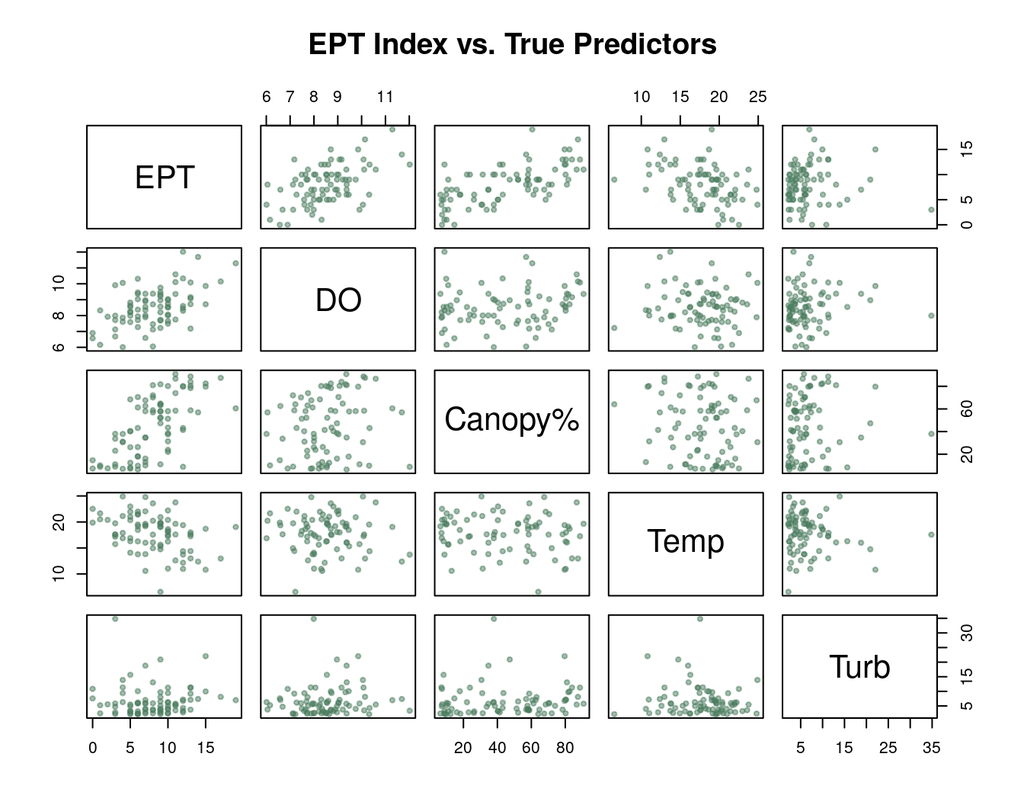

Scatterplot matrix of the response (EPT index) against the four true predictors. The relationships are visible but noisy, which is realistic for field data.

```r
wq |>
  select(EPT_index, DO_mgl, canopy_cover, temp_C, turbidity) |>
  pairs(
    pch = 20, col = adjustcolor("#4a7c5e", alpha.f = 0.5),
    main = "EPT Index vs. True Predictors",
    labels = c("EPT", "DO", "Canopy%", "Temp", "Turb")
  )
```

## 5. The OLS Problem: Why 14 Predictors is Too Many

Before fitting LASSO, let us see what happens when you naively fit OLS with all 14 predictors.

```r
ols_full <- lm(EPT_index ~ ., data = wq)
summary(ols_full)
```

```
#>
#> Call:
#> lm(formula = EPT_index ~ ., data = wq)
#>
#> Residuals:
#>    Min     1Q Median     3Q    Max
#> -4.744 -1.288 -0.042  1.263  5.051
#>
#> Coefficients:
#>                Estimate Std. Error t value Pr(>|t|)
#> (Intercept)    1.494342   6.077769   0.246 0.806557
#> temp_C        -0.252982   0.073164  -3.458 0.000966 ***
#> pH             0.153726   0.624361   0.246 0.806293
#> conductivity  -0.002966   0.002456  -1.208 0.231605
#> turbidity     -0.076730   0.049358  -1.555 0.124903
#> DO_mgl         1.235070   0.228630   5.402 1.00e-06 ***
#> nitrate_mgl   -0.381139   0.298109  -1.279 0.205611
#> phosphate_mgl  0.128826   0.803318   0.160 0.873089
#> chlorophyll_a  0.030759   0.111875   0.275 0.784231
#> TSS_mgl        0.058437   0.028998   2.015 0.048022 *
#> BOD_mgl       -0.169065   0.131446  -1.286 0.202936
#> alkalinity    -0.011495   0.008564  -1.342 0.184183
#> hardness      -0.008308   0.007006  -1.186 0.239994
#> flow_velocity  0.005058   0.562367   0.009 0.992851
#> canopy_cover   0.087193   0.010846   8.039 2.49e-11 ***
#> ---
#> Signif. codes:  0 '***' 0.001 '**' 0.01 '*' 0.05 '.' 0.1 ' ' 1
#>
#> Residual standard error: 2.191 on 65 degrees of freedom
#> Multiple R-squared:  0.7348, Adjusted R-squared:  0.6776
#> F-statistic: 12.86 on 14 and 65 DF,  p-value: 9.349e-14
```

### Symptoms of overfitting

```r
cat("Number of predictors:", length(coef(ols_full)) - 1, "\n")
```

```
#> Number of predictors: 14
```

```r
cat("Number of observations:", nrow(wq), "\n")
```

```
#> Number of observations: 80
```

```r
cat("Ratio n/p:", round(nrow(wq) / (length(coef(ols_full)) - 1), 1), "\n")
```

```
#> Ratio n/p: 5.7
```

```r
cat("R-squared:", round(summary(ols_full)$r.squared, 3), "\n")
```

```
#> R-squared: 0.735
```

```r
cat("Adjusted R-squared:", round(summary(ols_full)$adj.r.squared, 3), "\n")
```

```
#> Adjusted R-squared: 0.678
```

With 80 observations and 14 predictors, the ratio $n/p \approx 5.7$. The model appears to fit well (high $R^2$), but much of this is overfitting. Several problems are visible in the summary:

**Spurious significance.** With 14 predictors tested simultaneously, some will appear significant by chance alone ($14 \times 0.05 = 0.7$ expected false positives at $\alpha = 0.05$).

**Unstable coefficients.** Remove a few data points and refit; the coefficients will change substantially. This instability is a hallmark of models that are too complex for the available data.

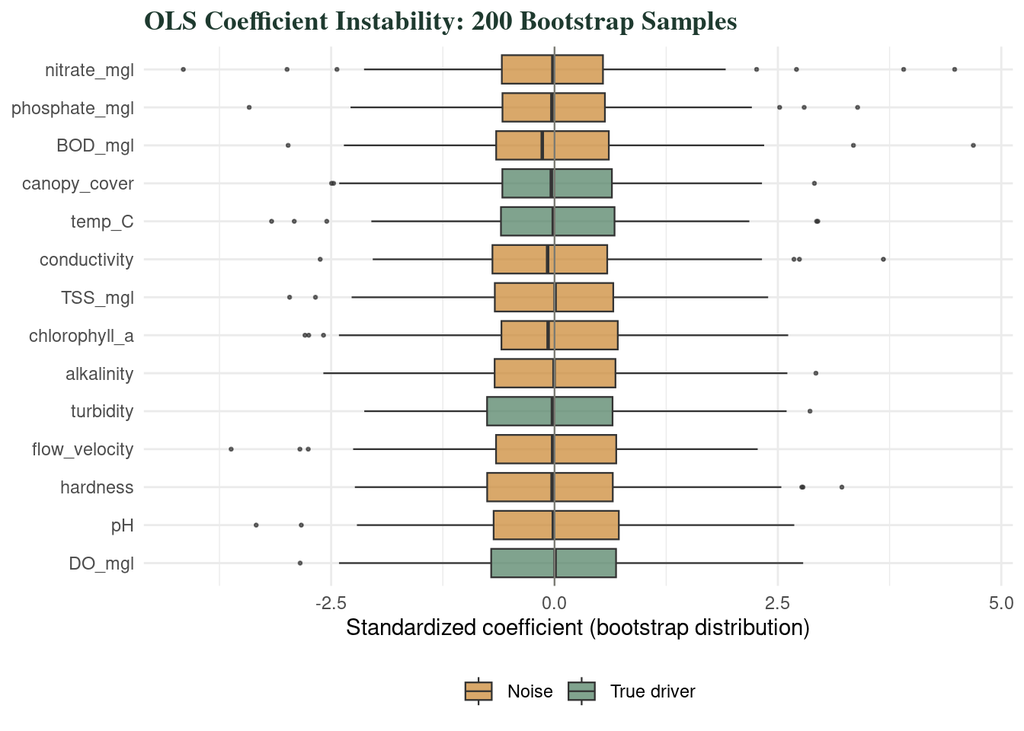

```r
set.seed(123)
n_boot <- 200
boot_coefs <- matrix(NA, n_boot, p)
colnames(boot_coefs) <- names(coef(ols_full))[-1]

for (i in 1:n_boot) {
  idx <- sample(n, replace = TRUE)
  fit <- lm(EPT_index ~ ., data = wq[idx, ])
  boot_coefs[i, ] <- coef(fit)[-1]
}

# Standardize for display
boot_std <- scale(boot_coefs)

boot_long <- as_tibble(boot_std) |>
  pivot_longer(everything(), names_to = "predictor", values_to = "coef") |>
  mutate(
    true_driver = predictor %in% c("DO_mgl", "canopy_cover",
                                    "temp_C", "turbidity"),
    predictor = fct_reorder(predictor, coef, .fun = function(x) median(abs(x)),
                            .desc = TRUE)
  )

ggplot(boot_long, aes(predictor, coef, fill = true_driver)) +
  geom_boxplot(alpha = 0.7, outlier.size = 0.5, linewidth = 0.4) +
  geom_hline(yintercept = 0, linewidth = 0.4, colour = "#7a7a72") +
  scale_fill_manual(values = c("TRUE" = "#4a7c5e", "FALSE" = "#c8832a"),
                    labels = c("Noise", "True driver"),
                    name = NULL) +
  coord_flip() +
  labs(x = NULL, y = "Standardized coefficient (bootstrap distribution)",
       title = "OLS Coefficient Instability: 200 Bootstrap Samples") +
  theme_minimal(base_size = 11) +
  theme(
    plot.title      = element_text(family = "serif", face = "bold",
                                    colour = "#1e3a2f"),
    legend.position = "bottom"
  )
```

## 6. Fitting LASSO with glmnet

The `glmnet` package requires data in matrix form, not formula syntax. This is the single most common source of errors for students coming from `lm()`.

### Preparing the data

```r
# Predictor matrix (no intercept, no response)
x <- as.matrix(wq |> select(-EPT_index))

# Response vector
y <- wq$EPT_index

cat("Dimensions of x:", nrow(x), "x", ncol(x), "\n")
```

```
#> Dimensions of x: 80 x 14
```

```r
cat("Length of y:", length(y), "\n")
```

```
#> Length of y: 80
```

**⚠️ glmnet does not accept formulas** Unlike `lm(EPT_index ~ ., data = wq)`, `glmnet()` requires a numeric matrix `x` and a numeric vector `y`. Use `model.matrix(~ . - 1, data = …)` if your data contains factors – this creates dummy variables automatically. Our dataset is all numeric, so `as.matrix()` suffices.

### The coefficient path

When you call `glmnet()`, it fits the model across a sequence of 100 lambda values (by default), from the largest lambda that sets all coefficients to zero down to a small lambda that is close to OLS. The result is a **coefficient path** showing how each predictor enters the model as the penalty relaxes.

```r
lasso_fit <- glmnet(x, y, alpha = 1)  # alpha = 1 is LASSO
```

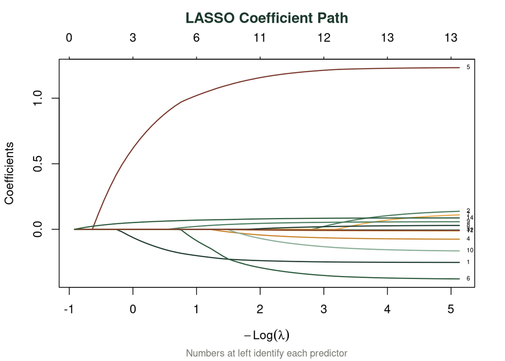

```r
plot(lasso_fit, xvar = "lambda", label = TRUE,
     col = rep(c("#1e3a2f", "#4a7c5e", "#8aad96", "#c8832a",
                 "#7a3a2f", "#2d5a3d", "#e8a84a"), 2),
     lwd = 1.5)
title("LASSO Coefficient Path", line = 2.5,
      font.main = 2, col.main = "#1e3a2f")
mtext("Numbers at left identify each predictor", side = 1, line = 4,
      cex = 0.8, col = "#7a7a72")
```

## 7. Choosing Lambda by Cross-Validation

The coefficient path shows the full solution set, but you need to pick one lambda to use. **K-fold cross-validation** selects the lambda that minimizes out-of-sample prediction error.

```r
set.seed(42)
cv_fit <- cv.glmnet(x, y, alpha = 1, nfolds = 10)
```

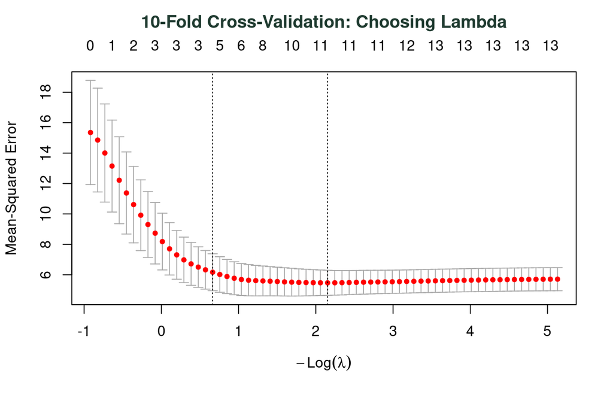

```r
plot(cv_fit, col = "#1e3a2f", lwd = 1.5)
title("10-Fold Cross-Validation: Choosing Lambda", line = 2.5,
      font.main = 2, col.main = "#1e3a2f")
```

### lambda.min vs. lambda.1se

```r
cat("lambda.min:", round(cv_fit$lambda.min, 4), "\n")
```

```
#> lambda.min: 0.1162
```

```r
cat("lambda.1se:", round(cv_fit$lambda.1se, 4), "\n")
```

```
#> lambda.1se: 0.5147
```

`cv.glmnet()` reports two special lambda values:

**lambda.min** is the lambda that minimizes the cross-validated MSE. This gives the best prediction accuracy, but may retain some noise predictors.

**lambda.1se** is the largest lambda whose MSE is within one standard error of the minimum. This is a more parsimonious model – it trades a tiny bit of prediction accuracy for a simpler, more interpretable model. For environmental science, where the goal is usually understanding (which variables matter?) rather than pure prediction, **lambda.1se is the better default**.

**✅ Rule of thumb: use lambda.1se for interpretation, lambda.min for prediction** If your goal is to identify which water quality parameters drive EPT richness, use `lambda.1se`. If your goal is to build the most accurate prediction of EPT at new sites, use `lambda.min`. When in doubt, report both.

## 8. Interpreting the Selected Model

### Extracting coefficients

```r
# Coefficients at lambda.1se
coefs_1se <- coef(cv_fit, s = "lambda.1se")
coefs_min <- coef(cv_fit, s = "lambda.min")

# Convert to tidy data frame
tidy_coefs <- function(coef_obj, label) {
  cf <- as.matrix(coef_obj)
  tibble(
    predictor   = rownames(cf),
    coefficient = cf[, 1],
    model       = label
  ) |>
    filter(predictor != "(Intercept)")
}

coef_df <- bind_rows(
  tidy_coefs(coefs_1se, "lambda.1se"),
  tidy_coefs(coefs_min, "lambda.min")
) |>
  mutate(selected = coefficient != 0)
```

```r
# lambda.1se results
coef_1se_display <- coef_df |>
  filter(model == "lambda.1se") |>
  arrange(desc(abs(coefficient))) |>
  mutate(
    status = ifelse(selected, "Selected", "Dropped"),
    true_driver = predictor %in% c("DO_mgl", "canopy_cover",
                                    "temp_C", "turbidity")
  )

kable(coef_1se_display |>
        select(predictor, coefficient, status, true_driver),
      digits = 4,
      col.names = c("Predictor", "LASSO Coefficient", "Status",
                     "True Driver?"),
      caption = "LASSO coefficients at lambda.1se. Predictors with coefficient = 0 have been dropped from the model. The 'True Driver' column shows whether LASSO correctly identified the variables that actually drive EPT in this simulated dataset.") %>%
  kable_styling(full_width = FALSE, font_size = 14) %>%
  column_spec(3, bold = TRUE)
```

LASSO coefficients at lambda.1se. Predictors with coefficient = 0 have been dropped from the model. The ‘True Driver’ column shows whether LASSO correctly identified the variables that actually drive EPT in this simulated dataset.

| Predictor | LASSO Coefficient | Status | True Driver? |
| --- | --- | --- | --- |
| DO_mgl | 0.9412 | Selected | TRUE |
| temp_C | -0.1736 | Selected | TRUE |
| canopy_cover | 0.0651 | Selected | TRUE |
| TSS_mgl | 0.0068 | Selected | FALSE |
| pH | 0.0000 | Dropped | FALSE |
| conductivity | 0.0000 | Dropped | FALSE |
| turbidity | 0.0000 | Dropped | TRUE |
| nitrate_mgl | 0.0000 | Dropped | FALSE |
| phosphate_mgl | 0.0000 | Dropped | FALSE |
| chlorophyll_a | 0.0000 | Dropped | FALSE |
| BOD_mgl | 0.0000 | Dropped | FALSE |
| alkalinity | 0.0000 | Dropped | FALSE |
| hardness | 0.0000 | Dropped | FALSE |
| flow_velocity | 0.0000 | Dropped | FALSE |

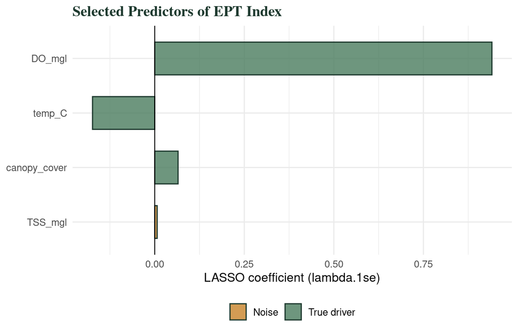

LASSO coefficients at lambda.1se. Only selected predictors have nonzero coefficients. Green bars are true drivers; orange bars are noise predictors. A successful LASSO selects all four true drivers and excludes most noise.

```r
coef_1se_display |>
  filter(selected) |>
  ggplot(aes(reorder(predictor, abs(coefficient)), coefficient,
             fill = true_driver)) +
  geom_col(alpha = 0.8, width = 0.6, colour = "#1e3a2f") +
  geom_hline(yintercept = 0, linewidth = 0.4) +
  scale_fill_manual(values = c("TRUE" = "#4a7c5e", "FALSE" = "#c8832a"),
                    labels = c("Noise", "True driver"), name = NULL) +
  coord_flip() +
  labs(x = NULL, y = "LASSO coefficient (lambda.1se)",
       title = "Selected Predictors of EPT Index") +
  theme_minimal(base_size = 12) +
  theme(
    plot.title      = element_text(family = "serif", face = "bold",
                                    colour = "#1e3a2f"),
    legend.position = "bottom"
  )
```

### Comparing lambda.min and lambda.1se

```r
compare_df <- coef_df |>
  select(predictor, coefficient, model) |>
  pivot_wider(names_from = model, values_from = coefficient) |>
  mutate(across(c(lambda.1se, lambda.min), ~ round(.x, 4)))

kable(compare_df,
      col.names = c("Predictor", "lambda.1se", "lambda.min"),
      caption = "Coefficients at both lambda values. lambda.min typically retains more predictors than lambda.1se.") %>%
  kable_styling(full_width = FALSE, font_size = 14)
```

Coefficients at both lambda values. lambda.min typically retains more predictors than lambda.1se.

| Predictor | lambda.1se | lambda.min |
| --- | --- | --- |
| temp_C | -0.1736 | -0.2410 |
| pH | 0.0000 | 0.0000 |
| conductivity | 0.0000 | -0.0021 |
| turbidity | 0.0000 | -0.0479 |
| DO_mgl | 0.9412 | 1.1692 |
| nitrate_mgl | 0.0000 | -0.3058 |
| phosphate_mgl | 0.0000 | 0.0000 |
| chlorophyll_a | 0.0000 | 0.0080 |
| TSS_mgl | 0.0068 | 0.0469 |
| BOD_mgl | 0.0000 | -0.0834 |
| alkalinity | 0.0000 | -0.0066 |
| hardness | 0.0000 | -0.0040 |
| flow_velocity | 0.0000 | 0.0000 |
| canopy_cover | 0.0651 | 0.0804 |

**📝 Try it: what happens with different seeds?** Cross-validation is stochastic – the fold assignments are random. Change `set.seed(42)` to `set.seed(99)` and re-run the `cv.glmnet()` call. Do the same predictors get selected? If the results change substantially, your signal-to-noise ratio is low and you should be cautious about interpreting the selection as definitive. Running CV multiple times and reporting the selection frequency across runs is a more honest approach.

## 9. Ridge Regression and Elastic Net

LASSO is one member of a family of penalized regression methods. The `glmnet` package implements all three through a single `alpha` parameter.

### The family

| Method | alpha | Penalty | Variable Selection? | Best When |
| --- | --- | --- | --- | --- |
| Ridge | 0 | $\lambda \sum \beta_j^2$ | No – shrinks but never zeros | Many weak predictors, all relevant |
| LASSO | 1 | $\lambda \sum \|\beta_j\|$ | Yes – sets some to exactly 0 | Sparse model, few true drivers |
| Elastic Net | 0 < alpha < 1 | $\lambda [\alpha \sum \|\beta_j\| + (1-\alpha) \sum \beta_j^2]$ | Yes – grouped selection | Correlated predictors, want groups |

### When to use each

**Ridge** ($\alpha = 0$) is preferred when you believe most predictors are relevant and you just want to stabilize coefficients. It handles multicollinearity better than LASSO because it does not force a choice among correlated predictors – it splits the effect equally.

**LASSO** ($\alpha = 1$) is preferred when you believe the true model is sparse – most predictors are noise and only a few matter. This is the most common scenario in environmental variable selection.

**Elastic net** ($0 < \alpha < 1$) is preferred when correlated predictors exist in groups and you want to select or exclude the whole group together. A common choice is $\alpha = 0.5$. If LASSO’s selection feels arbitrary among correlated predictors (keeping nitrate but dropping phosphate, or vice versa, depending on the random seed), elastic net will tend to keep both or drop both.

```r
# Fit ridge and elastic net for comparison
ridge_fit <- glmnet(x, y, alpha = 0)
enet_fit  <- glmnet(x, y, alpha = 0.5)
```

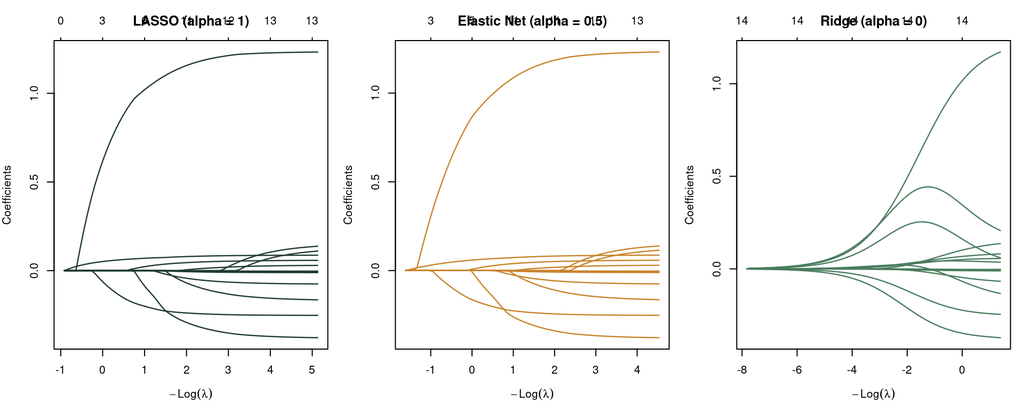

Coefficient paths for LASSO (left), elastic net (center), and ridge (right). LASSO produces exact zeros; ridge never does; elastic net is intermediate. The number at the top of each panel shows how many nonzero coefficients remain at each lambda.

```r
par(mfrow = c(1, 3), mar = c(4.5, 4, 3, 1))

plot(lasso_fit, xvar = "lambda", main = "LASSO (alpha = 1)",
     col = "#1e3a2f", lwd = 1.2)
plot(enet_fit, xvar = "lambda", main = "Elastic Net (alpha = 0.5)",
     col = "#c8832a", lwd = 1.2)
plot(ridge_fit, xvar = "lambda", main = "Ridge (alpha = 0)",
     col = "#4a7c5e", lwd = 1.2)
```

```r
par(mfrow = c(1, 1))
```

**💡 The grouped selection property of elastic net** When two predictors are highly correlated (say conductivity and hardness, with $r = 0.85$), LASSO will arbitrarily keep one and drop the other. Which one it keeps can change across CV folds. Elastic net tends to keep both or drop both, which is more scientifically interpretable when you know the predictors measure related constructs. If your coefficient path shows two correlated predictors trading places across lambda values, switch to elastic net.

## 10. Diagnostics and Validation

### Prediction accuracy

```r
# Predicted values at lambda.1se
y_pred <- predict(cv_fit, newx = x, s = "lambda.1se")[, 1]

# In-sample metrics
residuals <- y - y_pred
rmse <- sqrt(mean(residuals^2))
r2   <- 1 - sum(residuals^2) / sum((y - mean(y))^2)

cat("LASSO (lambda.1se):\n")
```

```
#> LASSO (lambda.1se):
```

```r
cat("  RMSE:", round(rmse, 2), "\n")
```

```
#>   RMSE: 2.33
```

```r
cat("  R²:  ", round(r2, 3), "\n")
```

```
#>   R²:   0.631
```

```r
# Compare to OLS
y_pred_ols <- predict(ols_full)
rmse_ols   <- sqrt(mean((y - y_pred_ols)^2))
r2_ols     <- summary(ols_full)$r.squared

cat("\nOLS (all 14 predictors):\n")
```

```
#>
#> OLS (all 14 predictors):
```

```r
cat("  RMSE:", round(rmse_ols, 2), "\n")
```

```
#>   RMSE: 1.98
```

```r
cat("  R²:  ", round(r2_ols, 3), "\n")
```

```
#>   R²:   0.735
```

**⚠️ In-sample R² is misleading for LASSO** The R² above is computed on the same data used to fit the model. For OLS with 14 predictors this is inflated by overfitting. The honest comparison is the cross-validated MSE from `cv.glmnet()`, which estimates out-of-sample performance. LASSO typically has lower in-sample R² than OLS but higher out-of-sample R² – that is the whole point of regularization.

### Residual plot

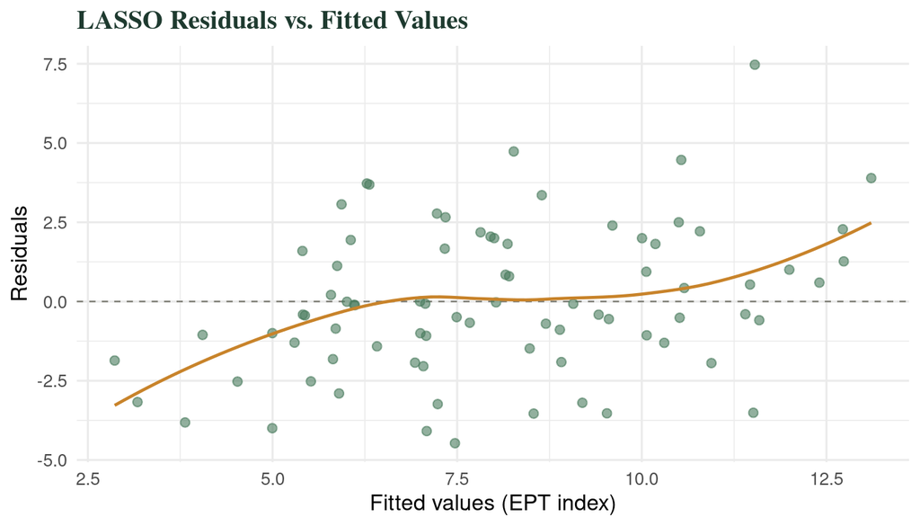

Residuals vs. fitted values for the LASSO model at lambda.1se. No systematic pattern should be visible; random scatter around zero indicates the model is adequate. Curvature would suggest a missing nonlinear term.

```r
resid_df <- tibble(fitted = y_pred, residual = residuals)

ggplot(resid_df, aes(fitted, residual)) +
  geom_hline(yintercept = 0, linewidth = 0.4, colour = "#7a7a72",
             linetype = "dashed") +
  geom_point(colour = "#4a7c5e", alpha = 0.6, size = 2) +
  geom_smooth(method = "loess", se = FALSE, colour = "#c8832a",
              linewidth = 0.8, span = 0.7) +
  labs(x = "Fitted values (EPT index)", y = "Residuals",
       title = "LASSO Residuals vs. Fitted Values") +
  theme_minimal(base_size = 12) +
  theme(
    plot.title = element_text(family = "serif", face = "bold",
                               colour = "#1e3a2f")
  )
```

### Selection stability via repeated CV

A single CV run depends on the random fold assignment. To assess stability, repeat the entire CV procedure many times and record which predictors are selected.

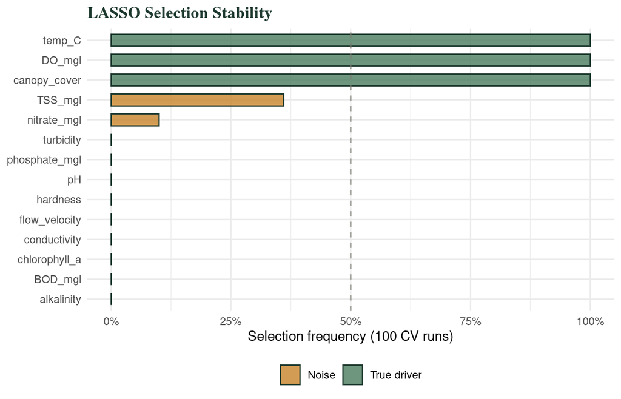

Selection frequency across 100 repeated cross-validation runs. A predictor selected in 90+ runs is a robust finding; one selected in 30-60 runs is uncertain.

```r
set.seed(2024)
n_repeats <- 100
selection_count <- rep(0, p)
names(selection_count) <- colnames(x)

for (i in 1:n_repeats) {
  cv_i <- cv.glmnet(x, y, alpha = 1, nfolds = 10)
  coefs_i <- coef(cv_i, s = "lambda.1se")[-1, 1]
  selection_count <- selection_count + (coefs_i != 0)
}

stability_df <- tibble(
  predictor = names(selection_count),
  frequency = selection_count / n_repeats,
  true_driver = predictor %in% c("DO_mgl", "canopy_cover",
                                  "temp_C", "turbidity")
) |>
  arrange(desc(frequency))

ggplot(stability_df, aes(reorder(predictor, frequency), frequency,
                          fill = true_driver)) +
  geom_col(alpha = 0.8, width = 0.6, colour = "#1e3a2f") +
  geom_hline(yintercept = 0.5, linetype = "dashed", colour = "#7a7a72") +
  scale_fill_manual(values = c("TRUE" = "#4a7c5e", "FALSE" = "#c8832a"),
                    labels = c("Noise", "True driver"), name = NULL) +
  scale_y_continuous(labels = percent_format()) +
  coord_flip() +
  labs(x = NULL, y = "Selection frequency (100 CV runs)",
       title = "LASSO Selection Stability") +
  theme_minimal(base_size = 11) +
  theme(
    plot.title      = element_text(family = "serif", face = "bold",
                                    colour = "#1e3a2f"),
    legend.position = "bottom"
  )
```

**💡 Stability selection is your honesty check** A predictor selected in 95 out of 100 repeated CV runs is a robust finding. A predictor selected in 40 out of 100 runs is borderline – it may or may not belong in the model, and you should not make strong claims about it. Reporting selection frequencies is more honest than reporting a single CV result, and it is straightforward to compute.

## 11. Reporting LASSO Results

### What to include in a methods section

When you use LASSO in a paper or report, include:

1. **The number of candidate predictors** and the sample size (n/p ratio).
2. **The software and version** (`glmnet` R package, version X.X).
3. **The alpha value** (1 for LASSO, or the elastic net value if used).
4. **How lambda was chosen** (10-fold CV, lambda.1se or lambda.min).
5. **The set of selected predictors** with their coefficients.
6. **A stability assessment** (repeated CV or bootstrap selection frequency).
7. **The CV-estimated prediction error** (MSE or RMSE).

### What to include in a results section

LASSO-selected predictors of EPT index (lambda.1se, 10-fold CV, 100 repetitions). Selection frequency indicates the proportion of repeated CV runs in which the predictor was retained.

| Predictor | LASSO Coefficient | Selection Frequency |
| --- | --- | --- |
| temp_C | -0.1736 | 1.00 |
| DO_mgl | 0.9412 | 1.00 |
| canopy_cover | 0.0651 | 1.00 |
| TSS_mgl | 0.0068 | 0.36 |
| nitrate_mgl | 0.0000 | 0.10 |

### Common pitfalls

| Pitfall | Why it matters | Solution |
| --- | --- | --- |
| Reporting only lambda.min | Overly complex model with noise predictors | Default to lambda.1se for interpretation |
| Single CV run | Selection depends on fold assignment | Report selection frequency over 50+ runs |
| Interpreting coefficient magnitude as importance | Correlated predictors split their effects | Standardize predictors for relative comparison |
| Ignoring multicollinearity | LASSO picks one of two correlated predictors arbitrarily | Use elastic net or inspect correlation matrix first |
| Treating LASSO as confirmatory | LASSO is exploratory variable selection | Validate on held-out data or a new sample |

**❌ Myth: “LASSO tells you the causal drivers”** LASSO identifies predictors with the strongest *predictive* association with the response, penalized for model complexity. It does not establish causation. A variable can be selected because it is a proxy for the true cause, or because it is correlated with one. Use LASSO output to generate hypotheses, then test them with designed experiments or mechanistic models.

#### 🔑 LASSO regression – key takeaways

- **LASSO adds a penalty to OLS** that forces weak coefficients to exactly zero. This gives you variable selection and model fitting in one step.
- **Use `glmnet(x, y, alpha = 1)`** to fit LASSO. The data must be in matrix form, not a formula. `glmnet` standardizes internally.
- **Choose lambda with cross-validation.** `cv.glmnet()` returns `lambda.min` (best prediction) and `lambda.1se` (simplest adequate model). Default to `lambda.1se` for interpretive goals.
- **The coefficient path plot is your roadmap.** Predictors that enter early (at high lambda) are the most important. Predictors that enter late are marginal.
- **Ridge, LASSO, and elastic net** are a family controlled by `alpha`. Use ridge when all predictors are plausibly relevant, LASSO when the model is sparse, elastic net when correlated predictors exist in groups.
- **Assess stability.** Repeat CV 50 to 100 times and report selection frequencies. A predictor selected in fewer than half the runs is not a robust finding.
- **LASSO is exploratory, not confirmatory.** It identifies the strongest predictive associations in your data. Treat the output as hypotheses to validate, not as established causal relationships.

### What’s next?

- **Multiple Regression & GLMs** – the OLS and AIC foundation that LASSO extends
- **Mixed-Effects Models** – when observations are grouped, combine LASSO variable selection with random effects
- **Simple Linear Regression** – review the OLS fundamentals that LASSO modifies
- **Correlation Analysis** – detecting the multicollinearity that motivates regularization